# Shrinkage Methods

Alexandra Chronopoulou

Lecture 17 R Examples

## Fat data set: Principal Components Analysis

Dimension of the human body in a study of 252 men. `brozek` and `siri` are the Percent body fat measure by the Brozek’s equation and Siri’s equation. Many of the body measurements are highly correlated.

```r
library(faraway)
data(fat)
dim(fat)
```

```
## [1] 252  18
```

```r
head(fat)
```

```
##   brozek siri density age weight height adipos  free neck chest abdom   hip
## 1   12.6 12.3  1.0708  23 154.25  67.75   23.7 134.9 36.2  93.1  85.2  94.5
## 2    6.9  6.1  1.0853  22 173.25  72.25   23.4 161.3 38.5  93.6  83.0  98.7
## 3   24.6 25.3  1.0414  22 154.00  66.25   24.7 116.0 34.0  95.8  87.9  99.2
## 4   10.9 10.4  1.0751  26 184.75  72.25   24.9 164.7 37.4 101.8  86.4 101.2
## 5   27.8 28.7  1.0340  24 184.25  71.25   25.6 133.1 34.4  97.3 100.0 101.9
## 6   20.6 20.9  1.0502  24 210.25  74.75   26.5 167.0 39.0 104.5  94.4 107.8
##   thigh knee ankle biceps forearm wrist
## 1  59.0 37.3  21.9   32.0    27.4  17.1
## 2  58.7 37.3  23.4   30.5    28.9  18.2
## 3  59.6 38.9  24.0   28.8    25.2  16.6
## 4  60.1 37.3  22.8   32.4    29.4  18.2
## 5  63.2 42.2  24.0   32.2    27.7  17.7
## 6  66.0 42.0  25.6   35.7    30.6  18.8
```

```r
cor(fat[,3:18])
```

```
##             density         age      weight      height      adipos        free
## density  1.00000000 -0.27763721 -0.59406188  0.09788114 -0.71473204 -0.00574871
## age     -0.27763721  1.00000000 -0.01274609 -0.17164514  0.11885126 -0.23790534
## weight  -0.59406188 -0.01274609  1.00000000  0.30827854  0.88735216  0.79219519
## height   0.09788114 -0.17164514  0.30827854  1.00000000 -0.02489094  0.48779841
## adipos  -0.71473204  0.11885126  0.88735216 -0.02489094  1.00000000  0.54719009
## free    -0.00574871 -0.23790534  0.79219519  0.48779841  0.54719009  1.00000000
## neck    -0.47296636  0.11350519  0.83071622  0.25370988  0.77785691  0.67911804
## chest   -0.68259865  0.17644968  0.89419052  0.13489181  0.91179865  0.59295714
## abdom   -0.79895463  0.23040942  0.88799494  0.08781291  0.92388010  0.49565221
## hip     -0.60933143 -0.05033212  0.94088412  0.17039426  0.88326922  0.70348104
## thigh   -0.55309098 -0.20009576  0.86869354  0.14843561  0.81270609  0.67668053
## knee    -0.49504035  0.01751569  0.85316739  0.28605321  0.71365983  0.70362435
## ankle   -0.26489003 -0.10505810  0.61368542  0.26474369  0.50031664  0.58294600
## biceps  -0.48710872 -0.04116212  0.80041593  0.20781557  0.74638418  0.64929534
## forearm -0.35164842 -0.08505555  0.63030143  0.22864922  0.55859425  0.55027717
## wrist   -0.32571598  0.21353062  0.72977489  0.32206533  0.62590659  0.67335898
##               neck      chest       abdom         hip      thigh        knee
## density -0.4729664 -0.6825987 -0.79895463 -0.60933143 -0.5530910 -0.49504035
## age      0.1135052  0.1764497  0.23040942 -0.05033212 -0.2000958  0.01751569
## weight   0.8307162  0.8941905  0.88799494  0.94088412  0.8686935  0.85316739
## height   0.2537099  0.1348918  0.08781291  0.17039426  0.1484356  0.28605321
## adipos   0.7778569  0.9117986  0.92388010  0.88326922  0.8127061  0.71365983
## free     0.6791180  0.5929571  0.49565221  0.70348104  0.6766805  0.70362435
## neck     1.0000000  0.7848350  0.75407737  0.73495788  0.6956973  0.67240498
## chest    0.7848350  1.0000000  0.91582767  0.82941992  0.7298586  0.71949640
## abdom    0.7540774  0.9158277  1.00000000  0.87406618  0.7666239  0.73717888
## hip      0.7349579  0.8294199  0.87406618  1.00000000  0.8964098  0.82347262
## thigh    0.6956973  0.7298586  0.76662393  0.89640979  1.0000000  0.79917030
## knee     0.6724050  0.7194964  0.73717888  0.82347262  0.7991703  1.00000000
## ankle    0.4778924  0.4829879  0.45322269  0.55838682  0.5397971  0.61160820
## biceps   0.7311459  0.7279075  0.68498272  0.73927252  0.7614774  0.67870883
## forearm  0.6236603  0.5801727  0.50331609  0.54501412  0.5668422  0.55589819
## wrist    0.7448264  0.6601623  0.61983243  0.63008954  0.5586848  0.66450729
##              ankle      biceps     forearm      wrist
## density -0.2648900 -0.48710872 -0.35164842 -0.3257160
## age     -0.1050581 -0.04116212 -0.08505555  0.2135306
## weight   0.6136854  0.80041593  0.63030143  0.7297749
## height   0.2647437  0.20781557  0.22864922  0.3220653
## adipos   0.5003166  0.74638418  0.55859425  0.6259066
## free     0.5829460  0.64929534  0.55027717  0.6733590
## neck     0.4778924  0.73114592  0.62366027  0.7448264
## chest    0.4829879  0.72790748  0.58017273  0.6601623
## abdom    0.4532227  0.68498272  0.50331609  0.6198324
## hip      0.5583868  0.73927252  0.54501412  0.6300895
## thigh    0.5397971  0.76147745  0.56684218  0.5586848
## knee     0.6116082  0.67870883  0.55589819  0.6645073
## ankle    1.0000000  0.48485454  0.41904999  0.5661946
## biceps   0.4848545  1.00000000  0.67825513  0.6321264
## forearm  0.4190500  0.67825513  1.00000000  0.5855883
## wrist    0.5661946  0.63212642  0.58558825  1.0000000
```

```r
# Consider circunference measurements
cfat<-fat[,9:18]
```

We obtain the principal components decomposition:

```r
#Use function prcomp to extract the Principal Components
pcfat<-prcomp(cfat)
names(pcfat)
```

```
## [1] "sdev"     "rotation" "center"   "scale"    "x"
```

```r
dim(pcfat)
```

[output not shown]

```r
summary(pcfat)
```

```
## Importance of components:
##                           PC1     PC2     PC3     PC4     PC5     PC6     PC7
## Standard deviation     15.990 4.06584 2.96596 2.00044 1.69408 1.49881 1.30322
## Proportion of Variance  0.867 0.05605 0.02983 0.01357 0.00973 0.00762 0.00576
## Cumulative Proportion   0.867 0.92304 0.95287 0.96644 0.97617 0.98378 0.98954
##                            PC8     PC9    PC10
## Standard deviation     1.25478 1.10955 0.52737
## Proportion of Variance 0.00534 0.00417 0.00094
## Cumulative Proportion  0.99488 0.99906 1.00000
```

The first principal component (PC1), explains 86.7% of the total data variation, while the first three components explain more than 95% of the total variation.

Since each principal component is a linear combination of the original data, we can inspect the elements of the rotation matrix to understand the PC meaning. This can be challenging in some cases. In particular the first column $u_1$ is:

```r
round(pcfat$rot[,1],2)
```

```
##    neck   chest   abdom     hip   thigh    knee   ankle  biceps forearm   wrist
##    0.12    0.50    0.66    0.42    0.28    0.12    0.06    0.15    0.07    0.04
```

This PC weights indicate that the first PC is a combination of all body measures with more weights on central body measurements `abdom`, `chest` and `hip`, and less weight on extremity measurements.

Since the central body measurements are larger and the PC decomposition depends on the variables scale, we should re-scale all variables before applying the PC method:

```r
pcfatr<-prcomp(cfat,scale=TRUE)
summary(pcfatr)
```

```
## Importance of components:
##                           PC1     PC2     PC3     PC4     PC5     PC6     PC7
## Standard deviation     2.6498 0.85301 0.81909 0.70114 0.54708 0.52831 0.45196
## Proportion of Variance 0.7021 0.07276 0.06709 0.04916 0.02993 0.02791 0.02043
## Cumulative Proportion  0.7021 0.77490 0.84199 0.89115 0.92108 0.94899 0.96942
##                            PC8     PC9   PC10
## Standard deviation     0.40539 0.27827 0.2530
## Proportion of Variance 0.01643 0.00774 0.0064
## Cumulative Proportion  0.98586 0.99360 1.0000
```

```r
round(pcfatr$rot[,1],2)
```

```
##    neck   chest   abdom     hip   thigh    knee   ankle  biceps forearm   wrist
##    0.33    0.34    0.33    0.35    0.33    0.33    0.25    0.32    0.27    0.30
```

Now all weights are very similar, and the first principal component represents an approximate average of all original variables explaining 70.2% of the total variation.

The remaining principal components will be orthogonal to the first one. The second principal component has negative values for the central body measurements and positive values for the extremity measurements, which indicates a contrats between these two groups of measurements. This will result in high score values (the *x* in pcfatr ) for observations with high extremity measures and low central body measurements; and low score values for observations with low extremity measurements and high central body measurements.

```r
round(pcfatr$rot[,2],2)
```

```
##    neck   chest   abdom     hip   thigh    knee   ankle  biceps forearm   wrist
##    0.00   -0.27   -0.40   -0.25   -0.19    0.02    0.62    0.02    0.36    0.38
```

```r
t(pcfatr$rot[,2])%*%pcfatr$rot[,1] # This product is zero
```

```
##               [,1]
## [1,] -9.714451e-17
```

PCA can be very sensitive to outliers, but detecting outliers in multiple dimensions is harder. If the m-dimensional data has a multivariate normal distribution, we can use the fact that the `mahalanobis distance` $d^2=(x-\mu)^\top\Sigma ^{-1} (x-mu) \sim \chi^2_m$. We can compare the theoretical quantiles of the $\chi^2$ with the observed mahalanobis distance to the center mean $\mu$ for each observation $x_i$. This can be calculated as the chi-square cdf inverse evaluated in $i/(n+1)$ where $i$ is the order of the distance $d_i$. We can use the function `cov.rob` from the `MASS` package to estimate the covariance matrix.

```r
library(MASS)
```

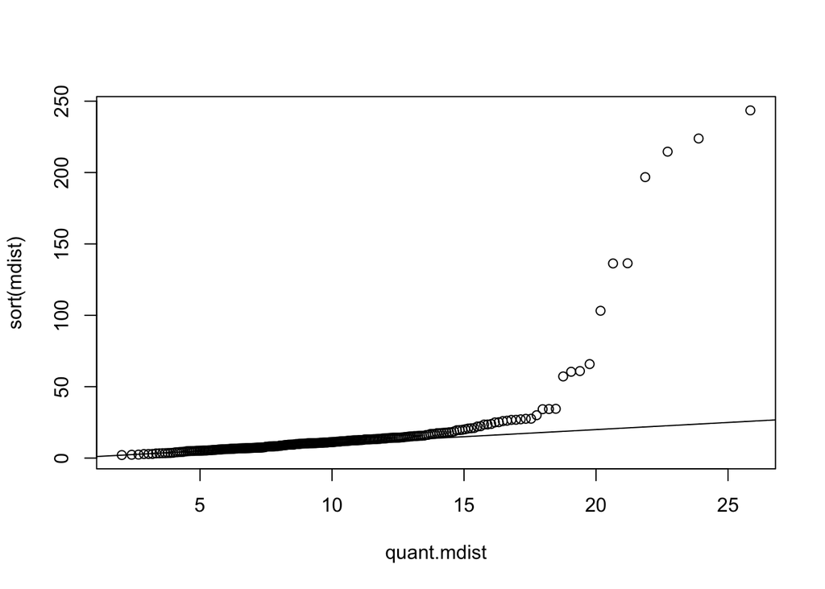

```r
sigfat<-cov.rob(cfat)
mdist<-mahalanobis(cfat,center=sigfat$center, cov=sigfat$cov)
n<-dim(cfat)[1]
p<-dim(cfat)[2]
quant.mdist<-qchisq(1:n/(n+1),p)
plot(quant.mdist,sort(mdist)); abline(0,1)
```

We could repeat the PCA after removing these points. You might like to try this.

Now we will use these PCA results in the regression. First we fit a model to `brozek` using the 10 original predictors, and fit a second model using the first two PCs. Note that the first model fit might be unstable since many predictors are correlated.

Since `abdom` has the largest weight in the first principal component, and `ankle` and `abdom` have the highest weights in the second component, we can select a combination of these two variables.

```r
moda<-lm(fat$brozek~.,data=cfat)
summary(moda) #Using all predictors
```

```
##
## Call:
## lm(formula = fat$brozek ~ ., data = cfat)
##
## Residuals:
##     Min      1Q  Median      3Q     Max
## -9.3159 -2.7435 -0.1584  2.8388 10.5150
##
## Coefficients:
##              Estimate Std. Error t value Pr(>|t|)
## (Intercept)  7.228749   6.214309   1.163  0.24588
## neck        -0.581947   0.208580  -2.790  0.00569 **
## chest       -0.090847   0.085430  -1.063  0.28866
## abdom        0.960229   0.071582  13.414  < 2e-16 ***
## hip         -0.391355   0.112686  -3.473  0.00061 ***
## thigh        0.133708   0.124922   1.070  0.28554
## knee        -0.094055   0.212394  -0.443  0.65828
## ankle        0.004222   0.203175   0.021  0.98344
## biceps       0.111196   0.159118   0.699  0.48533
## forearm      0.344536   0.185511   1.857  0.06450 .
## wrist       -1.353472   0.471410  -2.871  0.00445 **
## ---
## Signif. codes:  0 '***' 0.001 '**' 0.01 '*' 0.05 '.' 0.1 ' ' 1
##
## Residual standard error: 4.071 on 241 degrees of freedom
## Multiple R-squared:  0.7351, Adjusted R-squared:  0.7241
## F-statistic: 66.87 on 10 and 241 DF,  p-value: < 2.2e-16
```

```r
modpcr<-lm(fat$brozek~pcfatr$x[,1:2]) #Using the fisrt two PCs
summary(modpcr)
```

```
##
## Call:
## lm(formula = fat$brozek ~ pcfatr$x[, 1:2])
##
## Residuals:
##      Min       1Q   Median       3Q      Max
## -17.6966  -3.6115  -0.1938   3.4381  20.8732
##
## Coefficients:
##                    Estimate Std. Error t value Pr(>|t|)
## (Intercept)         18.9385     0.3291  57.542   <2e-16 ***
## pcfatr$x[, 1:2]PC1   1.8420     0.1245  14.800   <2e-16 ***
## pcfatr$x[, 1:2]PC2  -3.5505     0.3866  -9.184   <2e-16 ***
## ---
## Signif. codes:  0 '***' 0.001 '**' 0.01 '*' 0.05 '.' 0.1 ' ' 1
##
## Residual standard error: 5.225 on 249 degrees of freedom
## Multiple R-squared:  0.5492, Adjusted R-squared:  0.5456
## F-statistic: 151.7 on 2 and 249 DF,  p-value: < 2.2e-16
```

Some of the coefficients signs for `moda` do not make sense. If we use the two PCs as predictors, the signs of the parameters can be interpreted in terms of the meaning of the PCs.

```r
pcfatr$rot[,1:2]
```

```
##               PC1         PC2
## neck    0.3272162 -0.00277082
## chest   0.3385170 -0.27329761
## abdom   0.3341249 -0.39848795
## hip     0.3477307 -0.25464325
## thigh   0.3327963 -0.19141446
## knee    0.3288933  0.02161851
## ankle   0.2465960  0.62464601
## biceps  0.3221654  0.02159095
## forearm 0.2701136  0.36276204
## wrist   0.2988210  0.37724388
```

```r
modcon<-lm(fat$brozek~scale(fat$abdom)+ I(scale(fat$ankle)-scale(fat$abdom)), data=cfat)
summary(modcon)
```

```
##
## Call:
## lm(formula = fat$brozek ~ scale(fat$abdom) + I(scale(fat$ankle) -
##     scale(fat$abdom)), data = cfat)
##
## Residuals:
##     Min      1Q  Median      3Q     Max
## -16.134  -3.390  -0.074   3.107  14.873
##
## Coefficients:
##                                        Estimate Std. Error t value Pr(>|t|)
## (Intercept)                             18.9385     0.2794  67.789  < 2e-16 ***
## scale(fat$abdom)                         5.7629     0.3284  17.548  < 2e-16 ***
## I(scale(fat$ankle) - scale(fat$abdom))  -0.9950     0.3140  -3.169  0.00172 **
## ---
## Signif. codes:  0 '***' 0.001 '**' 0.01 '*' 0.05 '.' 0.1 ' ' 1
##
## Residual standard error: 4.435 on 249 degrees of freedom
## Multiple R-squared:  0.6752, Adjusted R-squared:  0.6726
## F-statistic: 258.8 on 2 and 249 DF,  p-value: < 2.2e-16
```

This model does a good job when compared with the full model with 10 predictors. The first predictor represents PC1 and the second predictor represents PC2. Scaled predictors work better in this case.

## Meatspec data set: Principal Components Analysis

We have data from 215 pure meat samples and 100 predictors coming from a Tecator Infratec Food and Feed Analyzer. The fat content was measured along with 100-channel spectrum of absorbances.

We split the data into:

- Training sample: First 172 observations
- Testing sample: Remaining 43 observations.

We can measure model performance using the Root Mean Square Error (RMSE): $\sqrt(\sum_{i=1}^n (y_i- \hat{y}_i )^2/n)$

```r
data(meatspec,package="faraway")
trainmeat<-meatspec[1:172,]
testmeat<-meatspec[173:215,]
mod1<-lm(fat~.,trainmeat)
summary(mod1)$r.sq
```

```
## [1] 0.9970196
```

```r
# function to calculate the rmse
rmse<-function(x,y) sqrt(mean((x-y)^2))
rmse(fitted(mod1), trainmeat$fat)
```

```
## [1] 0.6903167
```

```r
rmse(predict(mod1,testmeat),testmeat$fat)
```

```
## [1] 3.814
```

Now use PCs to predict the response and compare the RMSE. We will use library `pls` and function `pcr` instead.

```r
library(pls)
modpcr<-pcr(fat ~ ., data=trainmeat,ncomp=50)
#summary(modpcr)
#RMSE with 4 PCAs
rmse(predict(modpcr,ncom=4),trainmeat$fat)
```

```
## [1] 4.064745
```

```r
rmse(predict(modpcr,testmeat,ncomp=4),testmeat$fat)
```

```
## [1] 4.533982
```

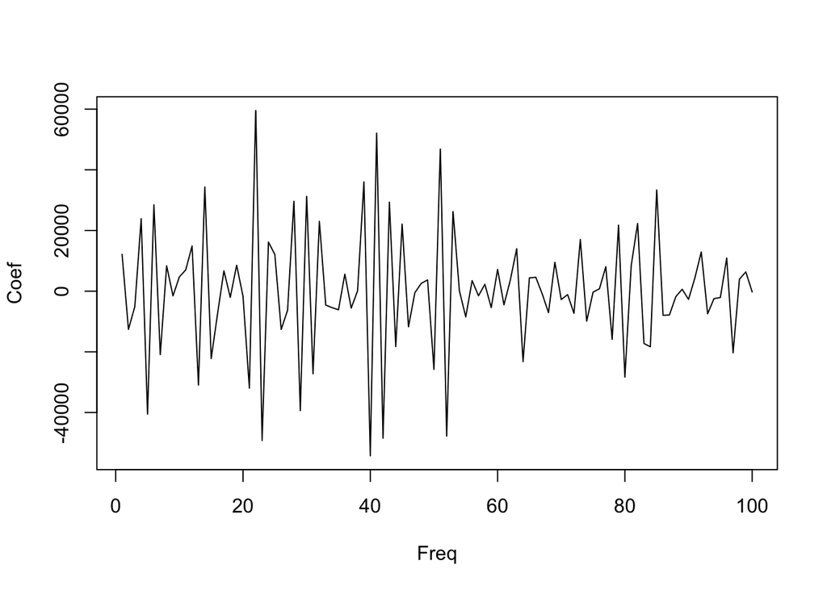

```r
#compare coefficients from LS estimate and PCR estimate
plot(mod1$coef[-1],xlab="Freq", ylab="Coef", type = "l")
```

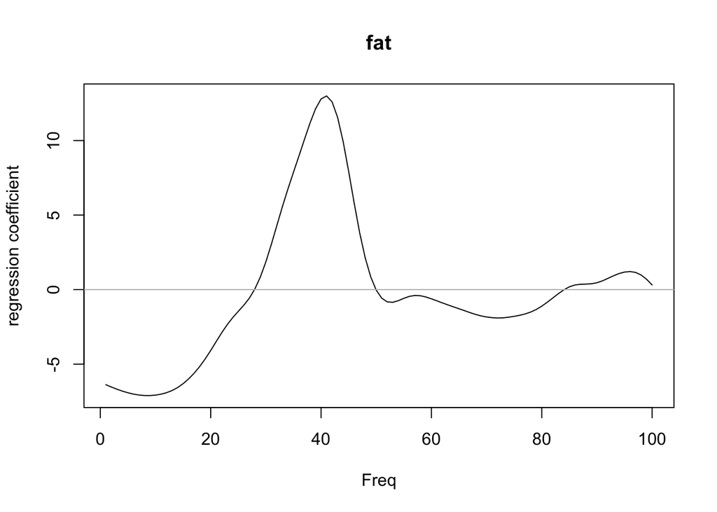

```r
coefplot(modpcr,ncomp=4,xlab="Freq")
```

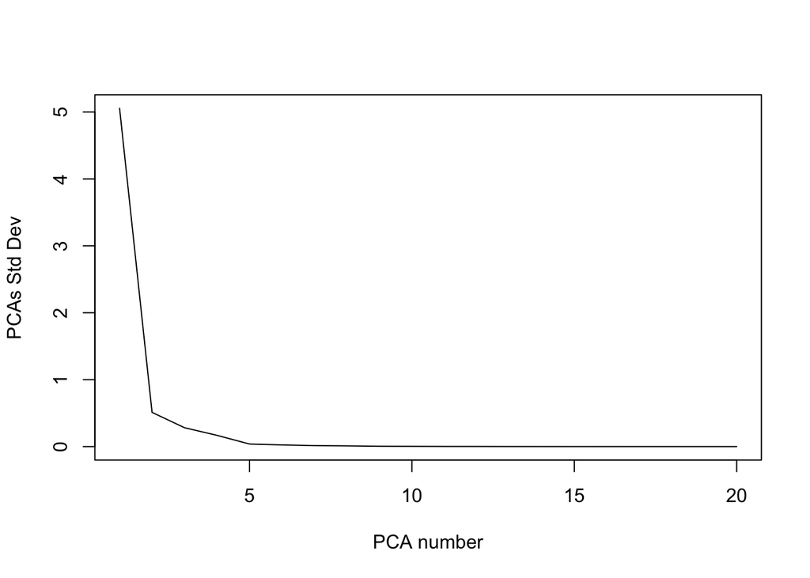

```r
#Why 4 PCAS? Use screeplot to figure this out.
meatpca<-prcomp(trainmeat[,-101])
plot(meatpca$sdev[1:20],ylab="PCAs Std Dev",xlab="PCA number",type="l")
```

Four PCs is a reasonable selection according to the `scree plot`. But we want to select enough number of PCs to minimize the RMSE.

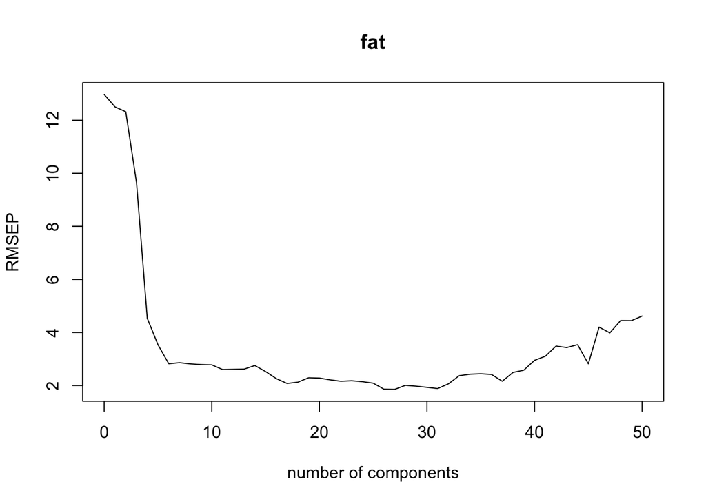

```r
set.seed(123)
# Minimize RMSE using function RMSEP
pcrmse<-RMSEP(modpcr,newdata=testmeat)
plot(pcrmse)
```

```r
which.min(pcrmse$val)
```

```
## [1] 28
```

```r
pcrmse$val[28]
```

```
## [1] 1.854858
```

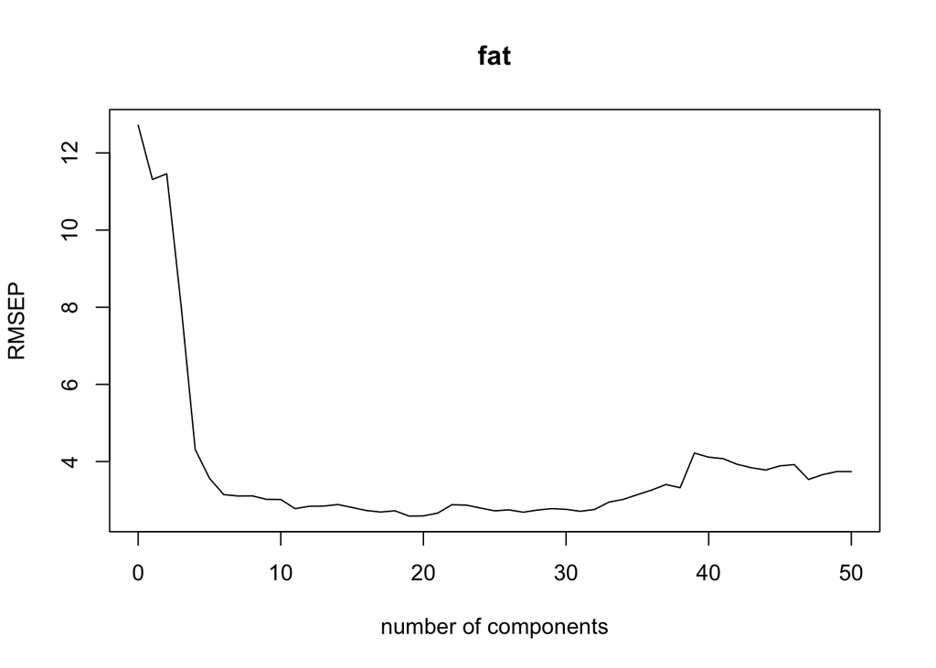

```r
#Use 10-fold Cros-Validation
set.seed(123)
modpcrcv<-pcr(fat~.,data=trainmeat,validation="CV",ncomp=50)
pcrCV<-RMSEP(modpcrcv,estimate="CV")
plot(pcrCV)
```

```r
which.min(pcrCV$val)
```

```
## [1] 20
```

```r
meatpred<-predict(modpcrcv,testmeat,ncomp=18)
rmse(meatpred,testmeat$fat)
```

```
## [1] 2.127134
```

With 18 PCs we get a RMSE on the test sample close to the smallest RMSE achieved of 1.854858 with 28 components.

## State data set: Ridge & LASSO Regression

We have data from 50 states:

- Population: population estimate as of July 1, 1975
- Income:per capita income (1974)
- Illiteracy:illiteracy (1970, percent of population)
- Life Exp:life expectancy in years (1969–71)
- Murder:murder and non-negligent manslaughter rate per 100,000 population (1976)
- HS Grad:percent high-school graduates (1970)
- Frost:mean number of days with minimum temperature below freezing (1931–1960) in capital or large city
- Area:land area in square miles

We want to predict *Life Expectancy*.

Use the function `lars` from library `lars` to fit a **lasso**

```r
library(lars)
data(state)
statedata<-data.frame(state.x77,row.names = state.abb)
head(statedata)
```

```
##    Population Income Illiteracy Life.Exp Murder HS.Grad Frost   Area
## AL       3615   3624        2.1    69.05   15.1    41.3    20  50708
## AK        365   6315        1.5    69.31   11.3    66.7   152 566432
## AZ       2212   4530        1.8    70.55    7.8    58.1    15 113417
## AR       2110   3378        1.9    70.66   10.1    39.9    65  51945
## CA      21198   5114        1.1    71.71   10.3    62.6    20 156361
## CO       2541   4884        0.7    72.06    6.8    63.9   166 103766
```

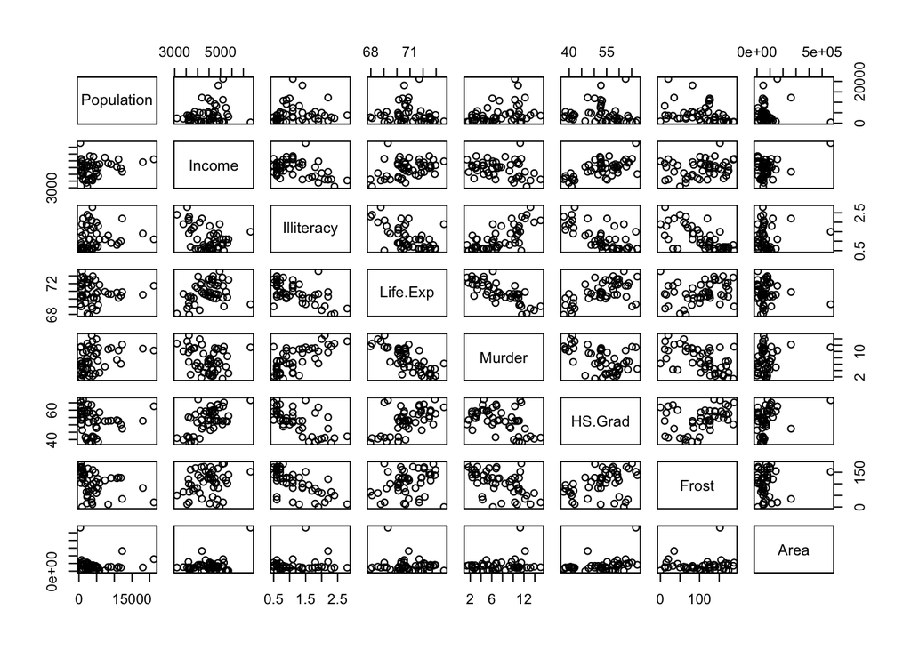

```r
plot(statedata)
```

```r
modls<-lm(Life.Exp~.,data=statedata)
summary(modls)
```

```
##
## Call:
## lm(formula = Life.Exp ~ ., data = statedata)
##
## Residuals:
##      Min       1Q   Median       3Q      Max
## -1.48895 -0.51232 -0.02747  0.57002  1.49447
##
## Coefficients:
##               Estimate Std. Error t value Pr(>|t|)
## (Intercept)  7.094e+01  1.748e+00  40.586  < 2e-16 ***
## Population   5.180e-05  2.919e-05   1.775   0.0832 .
## Income      -2.180e-05  2.444e-04  -0.089   0.9293
## Illiteracy   3.382e-02  3.663e-01   0.092   0.9269
## Murder      -3.011e-01  4.662e-02  -6.459 8.68e-08 ***
## HS.Grad      4.893e-02  2.332e-02   2.098   0.0420 *
## Frost       -5.735e-03  3.143e-03  -1.825   0.0752 .
## Area        -7.383e-08  1.668e-06  -0.044   0.9649
## ---
## Signif. codes:  0 '***' 0.001 '**' 0.01 '*' 0.05 '.' 0.1 ' ' 1
##
## Residual standard error: 0.7448 on 42 degrees of freedom
## Multiple R-squared:  0.7362, Adjusted R-squared:  0.6922
## F-statistic: 16.74 on 7 and 42 DF,  p-value: 2.534e-10
```

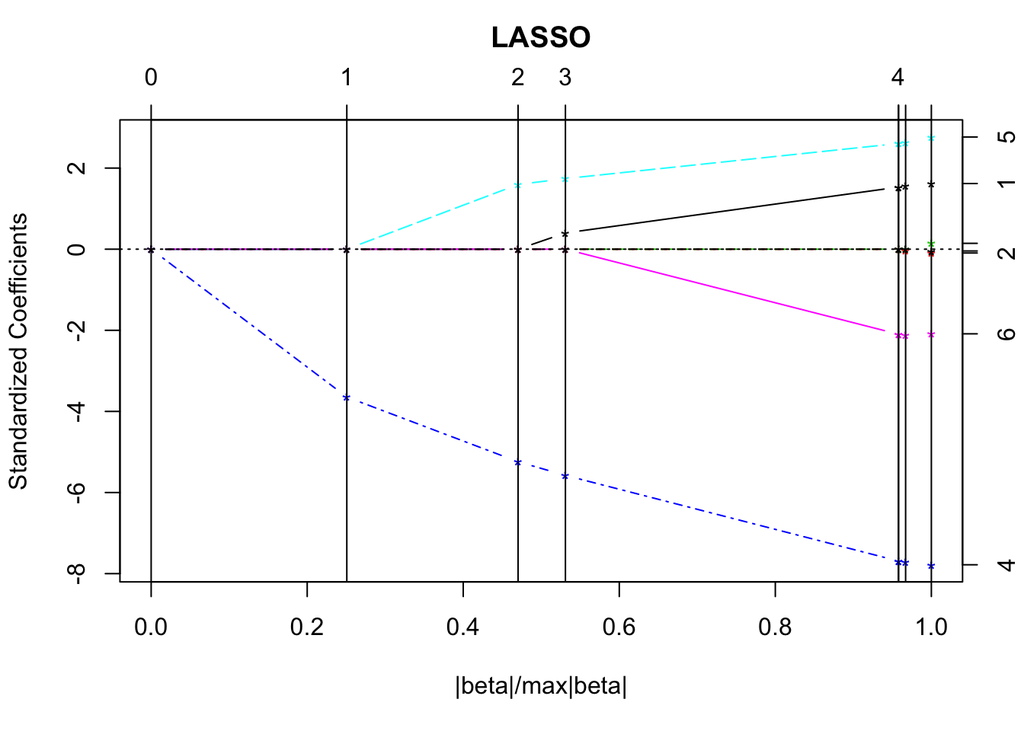

```r
#No model equation in function lars
modlasso<-lars(as.matrix(statedata[,-4]),statedata$Life.Exp)
plot(modlasso) #standardized coefficients vs t (restriction upper limit)
```

The x axis is the value of the L1 norm of the coefficients relative to the norm of the LS solution `t`. As this value increases more predictors enter into the model. For small values of `t` only `murder` stays active. For larger values of `t`, variables `HS.Grad` `Population` and `Frost` enter into the model. The optimal value of `t` can be selected by Cross-validation:

```r
set.seed(123)
cvmodlasso<-cv.lars(as.matrix(statedata[,-4]),statedata$Life.Exp)
```

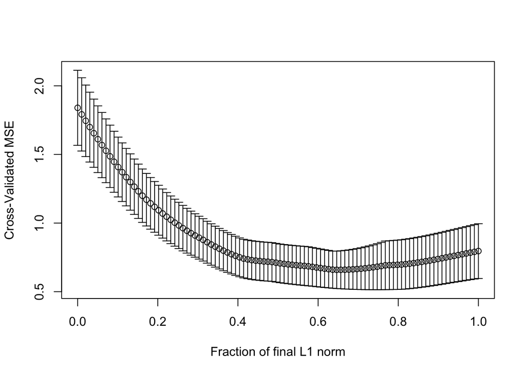

```r
sv<-cvmodlasso$index[which.min(cvmodlasso$cv)]
sv
```

```
## [1] 0.6464646
```

```r
#Lasso coefficients
predict(modlasso,s=sv,type="coef",mode="fraction")$coef
```

```
##    Population        Income    Illiteracy        Murder       HS.Grad
##  2.259631e-05  0.000000e+00  0.000000e+00 -2.379447e-01  3.492634e-02
##         Frost          Area
## -1.558616e-03  0.000000e+00
```

```r
#use help(predict.lars for more details)
#LS coefficients
coef(lm(Life.Exp~Population+Murder+HS.Grad+Frost,data=statedata))
```

```
##   (Intercept)    Population        Murder       HS.Grad         Frost
##  7.102713e+01  5.013998e-05 -3.001488e-01  4.658225e-02 -5.943290e-03
```

The lasso coefficients are shrunk with respect to the LS coefficients.

## Meat data set: Ridge & LASSO Regression

```r
trainy<-trainmeat$fat
trainx<-as.matrix(trainmeat[,-101])
```

We construct a ridge trace plot to determine the appropriate range of $\lambda$. Using generalized cross validation (GCV) to obtain $\lambda$.

```r
require (MASS)
rgmod <- lm.ridge(fat~., trainmeat, lambda=seq(0, 5e-8, len=21))
matplot(rgmod$lambda, coef(rgmod), type="l", xlab=expression(lambda), ylab=expression(hat(beta)), col=1)
which.min(rgmod$GCV)
```

```
## 1.75e-08
##        8
```

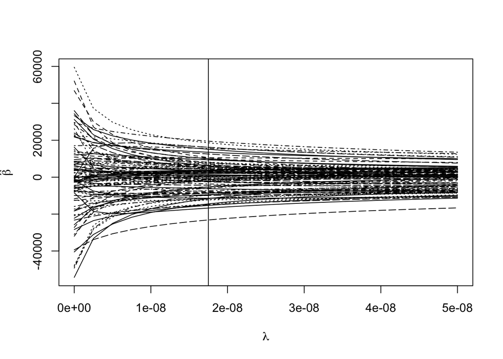

```r
abline(v=1.75e-08 )
```

We first compute the training sample performance:

```r
ypred <- cbind(1, as.matrix(trainmeat[,-101]))%*% coef(rgmod)[8,]
rmse(ypred, trainmeat$fat)
```

```
## [1] 0.8024395
```

and the test sample performance:

```r
ypred <- cbind(1, as.matrix(testmeat[,-101]))%*% coef(rgmod)[8,]
rmse(ypred, testmeat$fat)
```

```
## [1] 4.101066
```

As we can see the ridge prediction is not good here.

Now, let’s look at the LASSO regression for this dataset. First, compute the lasso fit:

```r
meatlasso<-lars(trainx,trainy)
```

Next, select the t using cross-validation:

```r
# Select t by CV
set.seed(123)
cvml<-cv.lars(trainx,trainy)
```

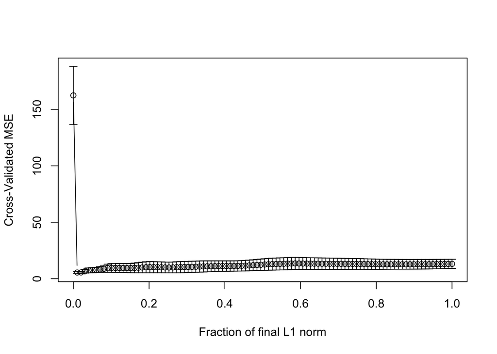

```r
which.min(cvml$cv)
```

```
## [1] 2
```

```r
svm<-cvml$index[which.min(cvml$cv)]
svm
```

```
## [1] 0.01010101
```

For this choice of t, compute the predicted value of the test data:

```r
# Compute predicted values for test data with selected t
testx<-as.matrix(testmeat[,-101])
predlasso<-predict(meatlasso,testx,s=svm,mode="fraction")
rmse(testmeat$fat,predlasso$fit)
```

```
## [1] 2.132223
```

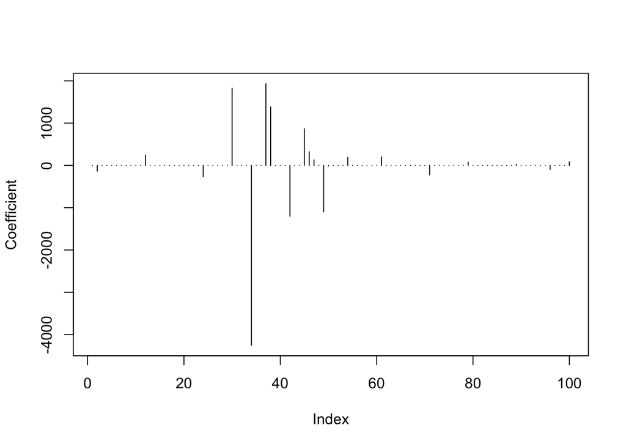

```r
#predicted lasso coefficients
predlasso<-predict(meatlasso,s=svm,type="coef",mode="fraction")
plot(predlasso$coef,type="h",ylab="Coefficient")
```

From the coefficients plot we can see that only few frequencies are used to predict the response, which is equivalent to a variable selection method result.